# Your Digest for Thursday, Aug 24, 2023 11:59 PM

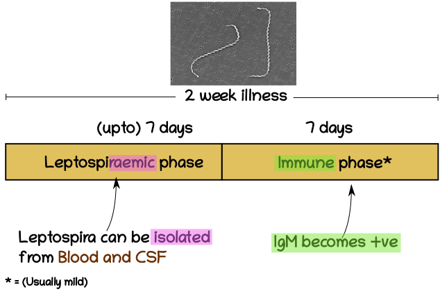

[output not shown]

### Thiamine and deficiency

[Source](https://www.ncbi.nlm.nih.gov/books/NBK482360/)  
Water soluble.  
Not stored in significant amounts-> constant intake required. (Present in whole grain, brown rise, nuts, beans, peas, and pork + poultry. )  
*Causes of low Thiamine*: Dietary deficiency and impaired absorption can cause deficiency. (Alcohol dependency, AIDS, post-bariatric surgery, pregnancy, lactation, haemodyalisys, renal failure, hyperthyroidism are all causes).  
The active form is *thiamine triphosphate* which is an essential co-enzyme in *glycolysis*, *Kreb's cycle, TCA cycle and overall metabolism of carbohydrates, lipids and amino acids*.

> [!TIP]  
> So, it makes sense that deficiency affects metabolically active tissues like heart and nerves.

#### Wernicke-Korsakoff syndrome

**Korsakoff syndrome:**

- chronic features, irreversible.
- Only notable for loss of short term memory and **confabulations**.
- Confabulations are a manifestation of *anterograde amnenia*.
- Impaired executive function - planning, problem solving, judgement.

> Anterograde amnesia (AA) - can't learn new thing  
> Retrograde Amnesia (RA) - Forgets old information

#### Beri beri

> Dry beriberi is the development of a symmetrical peripheral neuropathy characterized by both sensory and motor impairments, mostly of the distal extremities.(peripheral neuropathy, muscle weakness, brisk tendon reflexes, seizures).

> Wet beriberi includes signs of cardiac involvement with cardiomegaly, cardiomyopathy, High output heart failure, peripheral edema, and tachycardia, in addition to neuropathy

### Symptoms of DKA

Shortness of breath <- acidosis  
abdominal pain, nausea, vomiting.

## DKA Vs. HHS (hyperosmolar hyperglycaemic state)

HHS is also known as hyperosmolar hyperglycaemic nonketotic state (HHNK)  
*HHS usually occurs with prexisting disease.*

- Serum glucose frequently exceeds 1000 in HHS but is usually in the 350-450 range.
- Two proposed reasons for observing lower glucose levels in DKA
  - Patients with DKA present earlier with symptoms. Symptoms of hyperosmolarity tend to present later. (so there's more time for hyperglycemia to develop)
  - Patients with DKA are younger and usually present early in the development of Diabetes. Young patients, and those with early diabetes have **elevated** GFR. Therefore, DKA patients usually have high GFR which causes a lot of glucose to be lost via the urine -> this limits serum glucose concentration.

> [!INFO] Definition of COPD  
> Chronic Obstructive Pulmonary Disease (COPD) is a heterogeneous lung condition characterized by chronic respiratory symptoms (dyspnea, cough, sputum production and/or exacerbations) due to abnormalities of the airways (bronchitis, bronchiolitis) and/or alveoli (emphysema) that cause persistent, often progressive, airflow obstruction.

**Diagnosis** only requires the presence of **non-reversible** airflow obstruction as evidenced by FEV1/FVC < 0.7 (in the appropriate clinical context).

In COPD, hyperinflation is caused by static and dynamic components. This leads to ineffiencient ventilation and is one cause for dyspnoea.

# Causes of lactic acidosis

Overview of lactate metabolism:  
Glucose is anaerobically converted to pyruvate by glycloysis (also called the Embden-Myerhof-Parnas pathway).  
Pyruvate can enter the Kreb's cycle within mitochondria Or it can be converted to lactate by the enzyme **lactate dehydrogenase**.  
Therefore, lactate and pyruvate exist in an equilibrium.

Some tissues (heart, liver and kidneys) can use lactate as an energy source by converting it back to pyruvate for use in aerobic metabolism.  
Alternatively, the liver and kidneys can convert lactate to glucose via gluconeogensis.  
The cycle of some organs converting glucose to lactate and other organs converting lactate to glucose is known as the **Cori cycle.**

## Types of lactic acidosis

Type A: Lactic acidosis occuring in association with tissue hypoperfusion or hypoxia.  
Strangely, it's causes include

1. Overproduction
2. AND *underutilization* as well? -

Type B: no clinical evidence of tissue hypoperfusion or hypoxia.

- B1: systemic disease (renal, liver failure, thiamine deficiency etc)
- B2: caused by drugs (biguanides, alcohol, iron, isoniazid, zidovudine, salicylates, valproate
- B3: inborn errors of metabolism

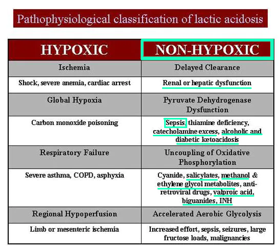

[Source](https://emedicine.medscape.com/article/167027-overview)

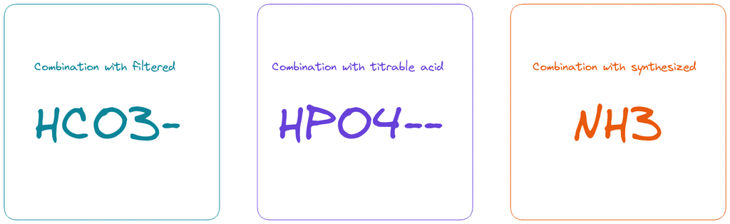

| HCO3 | HPO42-- | NH3 |  
| ------------------------------------ | ------------------- | ------------------------------- |  
| Obligatory for life | Cannot be regulated | Upregulated in response to acid |  
| (i.e to prevent continued HCO3 loss) | | (how? acidosis activates enzymes involved in glutamine metabolism -> more ammonia and ammonium can be made) |

> When H+ binds with phosphate and ammonia buffers, the kidney begins to use CO2 from the blood, to produce *new* bicarbonate  
> + **Aldosterone** increases action of this pump.  
> ==The main method of compensation for metabolic acidosis is respiratory washout if CO2.  
> However, the kidney does it's part by producing new bicarbonate so that more H+ can be mopped up by the ongoing acidosis.  
> Note that this will not cause the bicarbonate level to increase above normal==

> On chemical grounds, a substance with a pKa of 6.1 should not be a good buffer at a pH of 7.4 if it were a simple buffer. The system is more complex as it is open at both ends (meaning both [HCO3] and pCO2 can be adjusted) and this greatly increases the buffering effectiveness of this system. The excretion of CO2 via the lungs is the key thing because of the rapidity of the response. The adjustment of pCO2 by change in alveolar ventilation has been referred to as physiological buffering.  
> [Source](https://www.youtube.com/watch?v=SqbMc6FYRn0&t=984s)